# Introduction to Python for Data Science & Statistics

What is Python · Installation & Setup · Python Environments

Author

Madhushani Perera

## 0.1 Python for Statistics

**A complete beginner-to-practitioner guide**

*“Python is the Swiss Army knife of data science — versatile, reliable, and always in your kit bag.”*  
— Rogel-Salazar, *Data Science and Analytics with Python* (2017)

## 0.2 🔵 Module 1 · What is Python?

History & Origin · Key Features · Why Python for Statistics?

# 1 What is Python?

## 1.1 History and Origin

### 1.1.1 Guido van Rossum and the Birth of Python

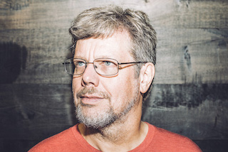

Guido van Rossum — Creator of Python (photo: Dan Stroud, CC BY)

👨‍💻

**Created by**  
Guido van Rossum

📅

**First release**  
February 1991

🏛️

**Origin**  
CWI, Netherlands

🎭

**Named after**  
Monty Python comedy

**Python** was created by **Guido van Rossum**, a Dutch programmer, who began work on it in December 1989 at Centrum Wiskunde & Informatica (CWI) in the Netherlands. The first public release — **Python 0.9.0** — appeared in February 1991.

**Note🎭 Why the name “Python”?**

The name has *nothing* to do with the snake. Van Rossum was a fan of *Monty Python’s Flying Circus* and wanted a short, unique, slightly quirky name. The snake branding came much later — and stuck!

**Key milestones in Python’s history:**

[figure not shown]

### 1.1.2 Python 2 vs Python 3

**Important⛔ Always Use Python 3 — No Exceptions**

Python 2 reached **End-of-Life on 1 January 2020**. All major scientific libraries (NumPy, pandas, SciPy, scikit-learn) have **dropped Python 2 support**. Install Python 3 — there is absolutely no reason to install Python 2 for new work.

| Feature | Python 2 ❌ (retired) | Python 3 ✅ (use this) |
| --- | --- | --- |
| `print` | `print "hello"` | `print("hello")` |
| Integer division | `5 / 2 → 2` | `5 / 2 → 2.5` |
| Strings | ASCII by default | Unicode (UTF-8) everywhere |
| `range()` | Returns a full list | Returns memory-efficient iterator |
| `input()` | Use `raw_input()` | `input()` works correctly |
| Status | ☠️ Dead (Jan 2020) | ✅ Actively developed |

### 1.1.3 Interpreted Language — What Does That Mean for Statistics?

Python is an **interpreted** language — code runs line-by-line, just like R. This is ideal for statistical work:

⚡

**Interactive**  
Run one line at a time in Jupyter

🔄

**Instant feedback**  
Change a parameter, re-run immediately

🧪

**Exploratory**  
Test one statistical test at a time

🤝

**Familiar**  
Works just like R’s interactive console

```python
# Run this line-by-line in any Python interpreter or Jupyter cell
import math
data       = [12.4, 15.6, 10.8, 14.2]
mean_val   = sum(data) / len(data)
variance   = sum((x - mean_val)**2 for x in data) / len(data)
std_approx = math.sqrt(variance)
print(f"Mean: {mean_val:.2f}   SD: {std_approx:.2f}")
# → Mean: 13.25   SD: 1.81
```

## 1.2 Key Features of Python

### 1.2.1 📖 Readable and Simple Syntax

Python enforces **indentation** (4 spaces) instead of braces `{}`. Code reads like structured English — critical when statisticians who are not software engineers need to read and verify the code.

```python
# ── Compute a one-sample t-statistic from scratch ─────────────────
# Anyone can follow this, even without a Python background
sample   = [22.1, 19.8, 23.4, 21.0, 20.5]
n        = len(sample)
mean     = sum(sample) / n
variance = sum((x - mean)**2 for x in sample) / (n - 1)   # Bessel's correction
std_err  = (variance / n) ** 0.5

t_stat   = (mean - 20) / std_err    # H₀: population mean = 20
print(f"n={n}   mean={mean:.2f}   t={t_stat:.3f}")
```

### 1.2.2 🆓 Open-Source and Free

**Tip💰 The entire Python data science stack is FREE**

| Tool | Cost in Python | Cost equivalent in proprietary software |
| --- | --- | --- |
| Core language | $0 | MATLAB: ~$500/yr (academic) |
| Statistical tests | $0 (scipy) | SPSS Base: ~$2,000/yr |
| Machine learning | $0 (scikit-learn) | SAS: ~$8,000/yr |
| Deep learning | $0 (TensorFlow/PyTorch) | No equivalent |

### 1.2.3 🌐 Large Community — the Ecosystem

[figure not shown]

## 1.3 Why Python for Statistics?

### 1.3.1 Python vs R, MATLAB, and SPSS

**Tip🤝 Python and R are **complementary**, not competitors**

Many professional statisticians and data scientists use **Python** for ML pipelines and production systems, and **R** for statistical modelling, publication-quality graphics (`ggplot2`), and academic communication. Both are worth learning.

| Criterion | 🐍 Python | 📊 R | 🔢 MATLAB | 📋 SPSS |
| --- | --- | --- | --- | --- |
| **Cost** | 🆓 Free | 🆓 Free | 💰 Expensive | 💰 Expensive |
| **Statistical tests** | ✅ scipy/statsmodels | ⭐ Best-in-class | ✅ Toolbox | ✅ Built-in |
| **Machine learning** | ⭐ Best-in-class | ✅ tidymodels | ✅ Toolboxes | ❌ Limited |
| **Data wrangling** | ✅ pandas | ✅ tidyverse | ⚠️ Moderate | ⚠️ Limited |
| **Reproducibility** | ✅ Jupyter/Quarto | ✅ R Markdown | ✅ Live scripts | ⚠️ Syntax files |
| **Learning curve** | 🟢 Gentle | 🟡 Moderate | 🟡 Moderate | 🟢 Gentle (GUI) |
| **Community size** | 🟣 Enormous | 🔵 Large academic | 🟠 Niche | 🔴 Declining |

[figure not shown]

## 1.4 🟢 Module 2 · Installation & Setup

Anaconda · pip & conda · Virtual Environments · Windows · macOS · Linux

# 2 Installation & Setup

**Note🎯 Recommended Approach for Beginners**

Install **Anaconda Individual Edition** — a single installer that gives you Python, the `conda` package manager, and **250+ pre-built scientific packages** (NumPy, pandas, SciPy, matplotlib, Jupyter) all in one go. This is the recommended starting point in both VanderPlas (2016) and Rogel-Salazar (2017).

📦 **What you get:** Python 3 · conda · Jupyter Notebook · JupyterLab · NumPy · pandas · SciPy · statsmodels · matplotlib · seaborn · scikit-learn — and 240 more packages.

## 2.1 Anaconda Distribution

### 2.1.1 What is Anaconda?

**Anaconda** is a free, open-source Python distribution purpose-built for data science.

📦

**All-in-one**  
250+ packages included

🔒

**Safe**  
Separate from system Python

🌍

**Cross-platform**  
Windows · macOS · Linux

🧩

**Environments**  
Isolate projects easily

### 2.1.2 Anaconda vs Miniconda

|  | Anaconda | Miniconda |
| --- | --- | --- |
| **Size** | ~3 GB | ~500 MB |
| **Included packages** | 250+ (ready to use) | Python + conda only |
| **Best for** | Beginners, most users | Advanced users, servers |
| **Setup time** | Install and go | Install, then `conda install` what you need |

**Tip💡 Recommendation**

If you have disk space, choose **Anaconda**. If disk space is tight or you’re on a server, choose **Miniconda**.

## 2.2 Step-by-Step Installation

**Important▶️ Watch the video for your platform, then follow the written steps below**

The videos below walk through each platform installation. Written steps follow each video.

### 2.2.1 Installation by Platform

**🪟 Windows**

**Estimated time:** 10–15 minutes · **Disk space needed:** ~3 GB

#### 2.2.1.1 📺 Video Tutorial — Windows Installation

▶ YouTube

[video not shown]

*How to Install Anaconda Python on Windows 11 — Step-by-Step Guide (2024)*

#### 2.2.1.2 Written Steps — Windows

1 **Download the installer**

Go to [**https://www.anaconda.com/download**](https://www.anaconda.com/download) and download:

`Anaconda3-YYYY.MM-Windows-x86_64.exe` (64-bit, most recent release)

> File size is approximately 800 MB. The website auto-detects your OS.

2 **Run the installer**

Double-click the downloaded `.exe` file. When the **Welcome Screen** appears, click **Next >**

> 💡 If Windows asks “Do you want to allow this app to make changes?”, click **Yes**.

3 **Accept the License Agreement**

Read the License Agreement and click **I Agree** to proceed.

4 **Choose installation type**

Select **Just Me (recommended)** unless you are an administrator installing for all users on the machine. Click **Next >**

5 **Choose install location**

Leave the default path as-is:  
`C:\Users\YourName\anaconda3`

Avoid paths with spaces or special characters. Click **Next >**

6 **Advanced installation options**

| Option | Setting | Why |
| --- | --- | --- |
| Add Anaconda3 to PATH | ☐ **Leave unchecked** | Avoids conflicts with other software |
| Register Anaconda3 as default Python | ☑ **Check this** | Ensures IDEs find the right Python |

Click **Install** and wait ~5–10 minutes.

7 **Finish & Verify**

Click **Finish**. Then open **Anaconda Prompt** from the Start Menu and run:

```bash
conda --version    # → conda 23.x.x
python --version   # → Python 3.11.x
```

**Tip🪟 Windows PATH Configuration**

During installation you were told **not** to add Anaconda to PATH. Instead, always open **Anaconda Prompt** (not the regular Command Prompt) — it sets PATH automatically.

To use Python in PowerShell, run this once in Anaconda Prompt:

```bash
conda init powershell
```

Then restart PowerShell.

**🍎 macOS**

**Estimated time:** 10–15 minutes · **Disk space needed:** ~3 GB

#### 2.2.1.3 📺 Video Tutorial — macOS Installation

▶ YouTube

[video not shown]

*Getting started with Anaconda and Python on a Mac — complete walkthrough (2024)*

#### 2.2.1.4 Written Steps — macOS

1 **Identify your Mac chip**

Click the 🍎 Apple menu → **About This Mac** and check the chip:

| Chip | Download file |
| --- | --- |
| Apple Silicon (M1/M2/M3/M4) | `Anaconda3-YYYY.MM-MacOSX-arm64.pkg` |
| Intel | `Anaconda3-YYYY.MM-MacOSX-x86_64.pkg` *(Intel builds ended Aug 2025)* |

> 💡 **All modern Macs from 2020 onwards use Apple Silicon (arm64).**

2 **Download the installer**

Go to [**https://www.anaconda.com/download**](https://www.anaconda.com/download) and select the correct `.pkg` file for your chip.

3 **Run the pkg installer**

Double-click the `.pkg` file and step through the wizard:  
**Introduction → Read Me → License → Destination → Installation Type → Install**

Enter your macOS password when prompted. Installation takes ~5–10 minutes.

4 **Verify**

Open **Terminal** (Applications → Utilities → Terminal) and run:

```bash
conda --version
python --version
which python    # Should show: /opt/anaconda3/bin/python (or ~/anaconda3/...)
```

**Warning⚠️ Do NOT modify macOS system Python**

macOS ships with its own Python used by the operating system. Anaconda installs a **completely separate** Python — do not replace or modify the system Python. After Anaconda installation, `python` in Terminal will point to the Anaconda Python.

**🐧 Linux**

**Estimated time:** 5–10 minutes · **Disk space needed:** ~3 GB

#### 2.2.1.5 📺 Video Tutorial — Linux (Ubuntu) Installation

▶ YouTube

[video not shown]

*Install Anaconda on Linux / Ubuntu — step-by-step terminal guide*

#### 2.2.1.6 Written Steps — Linux (Ubuntu / Debian)

1 **Update system packages**

```bash
sudo apt-get update
# Optional: install GUI dependencies (needed for Anaconda Navigator)
sudo apt-get install libgl1-mesa-glx libegl1-mesa libxrandr2 libxss1 libxcursor1 libxcomposite1 libasound2 libxi6 libxtst6
```

2 **Download the installer**

Go to [**https://www.anaconda.com/download**](https://www.anaconda.com/download) and copy the download link, or use `wget` directly:

```bash
cd ~/Downloads
wget https://repo.anaconda.com/archive/Anaconda3-2024.10-1-Linux-x86_64.sh
# Replace the filename with the current release from anaconda.com/download
```

3 **Run the installer**

```bash
bash ~/Downloads/Anaconda3-*.sh
```

Follow the prompts:

- Press **Enter** to read the license (Space to scroll quickly)
- Type **`yes`** to accept the license
- Press **Enter** to confirm default install location `~/anaconda3`
- Type **`yes`** to run `conda init` (adds conda to your shell)

4 **Reload shell & verify**

```bash
source ~/.bashrc          # Reload shell config
conda --version           # → conda 23.x.x
python --version          # → Python 3.11.x
conda info                # → Full installation details
```

**Tip🐧 Remote Linux Server (HPC / Cloud)?**

Run Jupyter on the server and tunnel it to your local browser:

```bash
# On the server:
jupyter notebook --no-browser --port=8888

# On your local machine (SSH tunnel in a separate terminal):
ssh -N -L 8888:localhost:8888 username@server.university.edu

# Then open in your browser: http://localhost:8888
```

### 2.2.2 📺 Universal Installation Guide (All Platforms)

▶ YouTube

[video not shown]

*How to Install Anaconda Python (2024) — covers download, setup, and Anaconda Navigator verification*

## 2.3 pip and conda — Package Managers

### 2.3.1 What is a Package Manager?

A **package manager** is like an app store for Python libraries — it installs, updates, and removes packages and their dependencies automatically.

🐍

**pip**  
Official Python manager, installs from PyPI

🅲

**conda**  
Anaconda’s manager, handles compiled libraries

🏪

**PyPI**  
500,000+ packages at pypi.org

🌿

**conda-forge**  
Community-maintained conda packages

### 2.3.2 conda — The Anaconda Way

`conda` manages both **packages** *and* **environments**, and handles non-Python compiled dependencies (C/Fortran libraries) that `pip` can’t always handle.

```bash
conda search scipy                           # Find a package
conda install scipy                          # Install into current environment
conda install scipy=1.11.0                   # Install specific version
conda install numpy pandas matplotlib seaborn  # Install multiple packages
conda update scipy                           # Update one package
conda update --all                           # Update everything
conda remove scipy                           # Remove a package
conda list                                   # Show all installed packages
conda env list                               # Show all environments
```

### 2.3.3 pip — The Python Standard Manager

```bash
pip install statsmodels                      # Install from PyPI
pip install statsmodels==0.14.0             # Specific version
pip install -r requirements.txt             # Install from a requirements file
pip install --upgrade statsmodels           # Upgrade
pip uninstall statsmodels                   # Remove
pip list                                    # List all installed
pip show numpy                              # Details about one package
```

### 2.3.4 conda vs pip — Decision Table

**Warning⚠️ Best Practice: conda first, pip as fallback**

Inside a conda environment, **prefer `conda install`**. Only use `pip` for packages not available via conda, and do so *after* all conda installs. Mixing carelessly can break environments.

| Situation | Use |
| --- | --- |
| Scientific packages (NumPy, SciPy, pandas) | ✅ `conda install` |
| Package only on PyPI, not in conda | ✅ `pip install` |
| Managing isolated project environments | ✅ `conda create` |
| Compiled C/Fortran extensions | ✅ `conda` preferred |
| Niche or personal packages | ✅ `pip install` |

### 2.3.5 Virtual Environments — Why They Matter

A **virtual environment** is an isolated Python installation. Each project gets its own Python version and package versions — they never interfere with each other.

[figure not shown]

```bash
# Create a fresh environment for your statistics project
conda create --name stats_project python=3.11

# Activate it (your prompt changes to: (stats_project) $)
conda activate stats_project

# Install all packages you need FOR THIS PROJECT ONLY
conda install numpy pandas scipy statsmodels matplotlib seaborn jupyter

# When done working, deactivate
conda deactivate

# Delete when no longer needed
conda env remove --name stats_project
```

## 2.4 🟡 Module 3 · Python Environment

IDE & Notebooks · Jupyter Notebook · JupyterLab · VSCode · Google Colab · Terminal

# 3 Python Environment — IDEs and Notebooks

## 3.1 Jupyter Notebook

### 3.1.1 What is Jupyter Notebook?

**Jupyter Notebook** is a web-based interactive environment where code, narrative text, equations, and visualisations all live in the same document. Each notebook file (`.ipynb`) contains **cells** that are either code or Markdown.

📝

**Narrative**  
Text + code + output together

🔁

**Reproducible**  
Restart & Run All = same result

📤

**Shareable**  
Export as HTML, PDF, slides

📊

**Visual**  
Charts appear inline below code

[figure not shown]

### 3.1.2 Launching Jupyter Notebook

**Note🖼️ Jupyter Notebook — Interface Overview**

[figure not shown]

Jupyter Notebook classic interface: the file browser (dashboard) shows your files and lets you create new notebooks.

**What you see above:** The **Jupyter Dashboard** (file browser). Click any `.ipynb` file to open it, or click **New → Python 3 (ipykernel)** in the top right to create a fresh notebook.

**Tip🖼️ Inside a Notebook — Code, Markdown, and Output Together**

[figure not shown]

An open Jupyter Notebook showing alternating Markdown cells (rendered text) and Code cells (with Python code and output inline below each cell).

**Anatomy of the notebook:** ① **Menu bar** (File / Edit / Cell / Kernel / Help). ② **Toolbar** (▶ Run, ⬛ Stop, ➕ Insert). ③ **Cell** — blue border = selected in command mode; green border = edit mode. ④ **Output** — plots and text appear directly below the code that generated them.

#### 3.1.2.1 Method 1 — Anaconda Navigator (GUI — easiest for beginners)

1 Open **Anaconda Navigator** from the Start Menu (Windows) or Applications (macOS)

2 Find the **Jupyter Notebook** tile and click **Launch**

3 Your browser opens automatically at `http://localhost:8888/tree`

4 Navigate to your project folder → click **New → Python 3** to create a notebook

**Note🖼️ Anaconda Navigator — What You Will See**

[figure not shown]

Anaconda Navigator home screen showing the Jupyter Notebook and JupyterLab launch tiles.

> **Key areas:** ① Home tab shows available applications. ② **Environments** tab (left sidebar) lets you switch conda environments. ③ Click the ▶ **Launch** button on any tile to open that tool.

#### 3.1.2.2 Method 2 — Command Line

```bash
conda activate stats_project                   # Activate your environment
jupyter notebook                               # Launch Jupyter
jupyter notebook --notebook-dir=~/Documents    # Or specify a folder
```

### 3.1.3 Cells, Kernels, and Output

#### 3.1.3.1 Cell Types

| Cell Type | Purpose | Keyboard shortcut to switch |
| --- | --- | --- |
| **Code** | Python that runs | Press `Y` in command mode |
| **Markdown** | Formatted text, headings, equations | Press `M` in command mode |
| **Raw** | Plain text (not rendered) | Press `R` in command mode |

#### 3.1.3.2 ⌨️ Essential Keyboard Shortcuts

**Tip⌨️ Jupyter Shortcuts Every Statistician Should Know**

| Shortcut | Action |
| --- | --- |
| `Shift + Enter` | ▶ Run cell, move to next |
| `Ctrl + Enter` | ▶ Run cell, stay here |
| `Esc` | Enter command mode (blue border) |
| `Enter` | Enter edit mode (green border) |
| `A` (command mode) | Insert cell **above** |
| `B` (command mode) | Insert cell **below** |
| `DD` (command mode) | Delete current cell |
| `M` (command mode) | Cell → Markdown |
| `Y` (command mode) | Cell → Code |
| `Z` (command mode) | Undo cell deletion |
| `Shift + M` | Merge selected cells |

#### 3.1.3.3 Magic Commands — Special Powers

Magic commands start with `%` (line magic) or `%%` (cell magic):

```python
# ── Display matplotlib plots inline (run once at top of notebook)
%matplotlib inline
%config InlineBackend.figure_format = 'retina'   # for crisp charts on high-resolution screens

# ── Time how long a computation takes
%timeit sum(range(1_000_000))

# ── Time an entire cell
%%timeit
import numpy as np
np.linalg.eig(np.random.randn(500, 500))

# ── See all variables in memory and their types
%whos

# ── Reload external Python files you have edited
%load_ext autoreload
%autoreload 2

# ── Run an external Python script inside your notebook
%run my_analysis_script.py

# ── List all available magic commands
%lsmagic
```

#### 3.1.3.4 The Kernel

**Important🔁 Always “Restart & Run All” before submitting or sharing**

The **kernel** is the Python process behind your notebook. Running cells out of order is a common source of errors. Before sharing your notebook, go to:

**Kernel → Restart & Run All Cells**

This re-runs every cell from top to bottom and confirms true reproducibility.

## 3.2 JupyterLab

### 3.2.1 What is JupyterLab?

**JupyterLab** is the next-generation interface — a full IDE experience in your browser. It is the recommended interface for most users today.

🗂️

**Tabbed layout**  
Multiple notebooks open at once

📁

**File browser**  
Left sidebar file explorer

💻

**Built-in terminal**  
Run shell commands without leaving browser

✏️

**Text editor**  
Edit `.py`, `.csv`, `.md` files directly

### 3.2.2 Launching JupyterLab

**Note🖼️ JupyterLab — Interface Overview**

[figure not shown]

JupyterLab interface showing the left sidebar file browser, a notebook tab open in the main work area.

**Key areas of JupyterLab:** ① **Left sidebar** — file browser, running kernels, extensions. ② **Main work area** — drag and drop tabs to tile notebooks side by side. ③ **Launcher** (+ tab) — quickly create notebooks, terminals, or open a text editor. ④ **Status bar** (bottom) — shows the active kernel and Python environment.

> 💡 **Tip for beginners:** JupyterLab looks more complex than Jupyter Notebook but works the same way at the notebook level. The extra panels (terminal, file editor, multiple tabs) become very useful as projects grow.

```bash
conda activate stats_project
jupyter lab           # Opens at http://localhost:8888/lab
```

## 3.3 Other IDEs

**💻 VSCode**

**Visual Studio Code** is a free, lightweight, highly extensible editor from Microsoft.

1 Download from [**https://code.visualstudio.com**](https://code.visualstudio.com)

2 Install the **Python** extension (by Microsoft)

3 Install the **Jupyter** extension (by Microsoft)

4 Open a `.ipynb` file — it renders as an interactive notebook

5 Select interpreter: `Ctrl+Shift+P` → **Python: Select Interpreter** → choose your conda env

```bash
# Install extensions from terminal
code --install-extension ms-python.python
code --install-extension ms-toolsai.jupyter
code --install-extension ms-python.pylance
```

**Best for:** Working on `.py` scripts and notebooks side-by-side, larger codebases.

**Note🖼️ VS Code — Python & Jupyter Interface**

[figure not shown]

VS Code editor with a Jupyter notebook (.ipynb) open in the main panel.

**Key areas:** ① **Activity Bar** (far left) — switch between Explorer, Search, Git, Extensions. ② **Notebook editor** (centre) — identical cell-based editing to Jupyter Notebook. ③ **Variable Explorer** (top right in notebook mode) — inspect live variables without extra code. ④ **Kernel selector** (top right, e.g. “Python 3.11 (stats_project)”) — click to change conda environment.

**🔴 PyCharm**

**PyCharm Community** (free) by JetBrains is a professional Python IDE.

| Feature | VSCode | PyCharm Community |
| --- | --- | --- |
| Cost | Free | Free |
| Jupyter in-editor | ✅ Excellent | ⚠️ Basic |
| Code debugging | ✅ Good | ⭐ Best-in-class |
| Code refactoring | ✅ Good | ⭐ Best-in-class |
| Best for | Notebooks + scripts | Large packages & applications |

Download from: https://www.jetbrains.com/pycharm/

**Note🖼️ PyCharm — Python IDE Interface**

[figure not shown]

PyCharm Community Edition IDE showing a Python script in the editor with syntax highlighting.

**Key areas:** ① **Project tree** (left) — all files in your project folder. ② **Editor** (centre) — smart code completion, error highlighting, and refactoring. ③ **Run / Debug tool window** (bottom) — output, errors, interactive console. ④ **Python Console** tab — type Python interactively, similar to IPython. ⑤ **Interpreter selector** (bottom right) — click to switch conda environments.

**☁️ Google Colab**

**Google Colaboratory** is a free, cloud-hosted Jupyter environment — **no installation required**.

Access at: [**https://colab.research.google.com**](https://colab.research.google.com)

| Feature | Value |
| --- | --- |
| Installation | None — browser only |
| Cost | Free (with limits) |
| GPU/TPU | ✅ Free access |
| Storage | Google Drive |
| Session timeout | ~12 hours (free) |
| Sensitive data | ⚠️ Not suitable |

```python
# Mount Google Drive for persistent storage
from google.colab import drive
drive.mount('/content/drive')

import pandas as pd
df = pd.read_csv('/content/drive/MyDrive/data/my_dataset.csv')
df.describe()
```

**How Colab compares to local Jupyter:**

| Feature | Google Colab | Local Jupyter/JupyterLab |
| --- | --- | --- |
| **Start time** | Instant (browser) | ~10 seconds (conda activate + jupyter lab) |
| **Free GPU** | ✅ Yes (T4/V100) | ❌ Depends on your hardware |
| **Works offline** | ❌ Requires internet | ✅ Fully offline |
| **Persistent files** | Via Google Drive only | Local disk (always available) |
| **Sensitive data** | ⚠️ Not recommended | ✅ Stays on your machine |
| **Package install** | `!pip install` per session | `conda install` once per env |

> **How to get started:** Go to colab.research.google.com, sign in with a Google account, and click **New notebook**. Your notebook is saved automatically to Google Drive.

**🖥️ Terminal / REPL**

For production work, automation, and server-side analysis:

```bash
# Run a Python script directly
python analysis.py

# Run with arguments
python analysis.py --input data.csv --output results.csv

# Interactive Python REPL
python

# IPython — enhanced REPL (included with Anaconda)
ipython

# Run a one-liner
python -c "import scipy; print(scipy.__version__)"
```

| Use Jupyter/JupyterLab | Use the terminal |
| --- | --- |
| Exploratory data analysis | Running finished analysis automatically |
| Teaching or presenting | Scheduled (cron) jobs |
| Sharing interactive reports | Processing data on a server |
| Learning Python | CI/CD pipelines |

## 3.4 Putting It All Together — Your First Statistical Session

**Note🚀 Complete Workflow: Launch → Analyse → Visualise**

Follow these steps to run your first real statistical analysis in Python.

### 3.4.1 Step 1 — Launch your environment

```bash
conda activate stats_project    # Activate your environment
cd ~/Documents/stats_project    # Navigate to your project
jupyter lab                     # Open JupyterLab
```

### 3.4.2 Step 2 — Set up your notebook

```python
# Cell 1: Import all libraries
import numpy as np
import pandas as pd
import scipy.stats as stats
import matplotlib.pyplot as plt
import seaborn as sns

sns.set_theme(style="whitegrid", palette="deep")
%matplotlib inline
%config InlineBackend.figure_format = 'retina'

print("✅ Libraries loaded successfully!")
print(f"   numpy   {np.__version__}")
print(f"   pandas  {pd.__version__}")
```

### 3.4.3 Step 3 — Create data and run a t-test

```python
# Cell 2: Simulate two groups and run an independent t-test
np.random.seed(2024)
control   = np.random.normal(loc=50, scale=10, size=30)
treatment = np.random.normal(loc=56, scale=10, size=30)

t_stat, p_value = stats.ttest_ind(control, treatment)
print(f"t-statistic = {t_stat:.3f}")
print(f"p-value     = {p_value:.4f}")
print("→ Statistically significant!" if p_value < 0.05 else "→ Not significant at α = 0.05")
```

### 3.4.4 Step 4 — Visualise

```python
# Cell 3: Boxplot + strip plot
fig, axes = plt.subplots(1, 2, figsize=(11, 5))

# Left: Boxplot
axes[0].boxplot([control, treatment], labels=["Control", "Treatment"],
                patch_artist=True,
                boxprops=dict(facecolor="#dbeafe", color="#1d4ed8"),
                medianprops=dict(color="#dc2626", linewidth=2))
axes[0].set_ylabel("Score")
axes[0].set_title(f"Independent t-test\nt = {t_stat:.2f},  p = {p_value:.4f}")

# Right: Distributions
x = np.linspace(20, 90, 300)
for grp, col, lbl in [(control,"#3b82f6","Control"),(treatment,"#ef4444","Treatment")]:
    mu, sd = grp.mean(), grp.std(ddof=1)
    axes[1].plot(x, stats.norm.pdf(x, mu, sd), linewidth=2.5, label=f"{lbl} (μ={mu:.1f})", color=col)
    axes[1].hist(grp, bins=12, density=True, alpha=0.25, color=col)
axes[1].set_xlabel("Score")
axes[1].set_ylabel("Density")
axes[1].set_title("Overlapping Distributions")
axes[1].legend()

plt.suptitle("First Statistical Analysis in Python", fontsize=13, fontweight="bold", y=1.02)
plt.tight_layout()
plt.show()
```

# 4 Summary and Next Steps

**Tip✅ Modules 1–3 at a Glance**

Modules 1–3 Summary

[output not shown]

### 4.0.1 📚 References

**Note📖 Recommended Reading**

1. **VanderPlas, J.** (2016). *Python Data Science Handbook: Essential Tools for Working with Data*. O’Reilly.  
   🌐 Free online: https://jakevdp.github.io/PythonDataScienceHandbook/
2. **Rogel-Salazar, J.** (2017). *Data Science and Analytics with Python*. CRC Press / Chapman and Hall.
3. **Python Software Foundation.** https://www.python.org
4. **Anaconda Inc.** https://www.anaconda.com/download
5. **Project Jupyter.** https://jupyter.org

### 4.0.2 🔜 Coming Up Next

| Module | Topics |
| --- | --- |
| **Python Basics** | Variables, data types, operators, control flow (`if`/`for`/`while`), functions, data structures (list/dict/tuple/set), modules & imports |
| **Key Libraries** | NumPy arrays & maths · pandas DataFrames · matplotlib/seaborn visualisation · SciPy statistical tests · statsmodels regression |
| **Capstone Project** | Load a real CSV → descriptive stats → hypothesis test → visualisation → Quarto report |